*Created by Shaunak Gadkari, Glen Waverley Secondary College 2019 - 9G1 using [Jupyter Notebook](https://jupyter.org/)*

‘Flying cars’ have been a popular retrostereotype of the present era - this is shown in many popular books and films dated back past the 90’s. But the idea is transitioning from a pipe dream to a possible reality - and with appropriate funding, a flying car could very well become the next Formula Grand Prix’s prize stallion.

# Design Thinking Routine

## What will your flying vehicle’s power source be?

### Considerations

For a flying car’s power source, there are mainly 4 things to be considered (order of descending priority): engine’s safety, engine’s weight, engine’s fuel consumption/efficiency, engine’s environmental footprint, engine’s scalability and the engine’s max thrust.

The engine’s safety is the most important factor. In fact, many rocket engines mounted onto manned capsules are often purposely limited in their power to stop them crushing the delicate humans inside with acceleration force. While actual figures vary due to the variation of body sizes and fat ratios which lead to inconsistent experimental results (as well as the ethical limitation of not being able to subject actual human bodies to considerable G forces), the morbidly named Euthanasia Coaster experiment [source 3] theorised via an experimental model that 1 minute of 10Gs of acceleration would be fatal to humans. 1G is 9.80665 m/s2 so we can show that 1 minute of approximately 98.0665m/s2 acceleration will kill. However, the real danger starts before that, especially with our task. Going up is much more dangerous because the blood flow to your brain is impeded by vertical acceleration. The human body can handle these high g-forces for a short amount of time - this is what makes rocket launches possible. However, within the scenario of this task, the person inside our car will have to take acceleration to extremely high speeds, as well as the horizontal force exerted when our car turns during laps. That is why it is important to consider the engine’s power and make appropriate strategies to handle the high speeds.

The engine’s weight and fuel consumption fall under the subcategory of mass – this is an extremely important factor as well. A conundrum with rocket science is that the more thrust you want, the more fuel you must put and the more powerful engine you must get. However, all this upgrading results in increased mass, requiring more thrust to lift, requiring more weight and so on. So, the obvious aim is to find a fuel efficient but still powerful engine. Luckily such engines are already being developed by companies such as NASA (SLR Launch System) and SpaceX (Merlin engines). Additionally, the engine must be able to run on small amounts of fuel over a long time – although it is true that cars with rocket engines have been developed, they cannot house enough fuel to last a standard Formula 1 race, only a large burst of speed at the start.

The engine’s scalability depends on whether it can be made smaller to fit onto a Formula 1 race car. It needs to be able to operate at the same relative efficiency even at the little sizes needed to be mounted onto a small vehicle.

The engine’s environmental footprint is important to reduce the impact that these races have on the environment. Cars and other assorted motor vehicles already are noticeably impacting the environment by releasing harmful exhaust gases into the air, and a major plus point for a propulsion method would be if it ran on a ‘green’ power source.

### Types of thrust

There are many different types of thrust available currently that can output enough power for out purposes. But selecting a specific subtype of thrust gives better control over accommodating for the factors mentioned above. There are two main types that are useful for this experiment:

#### Propeller thrust

Propeller thrust is used in many applications, such as motorboats and helicopters. It is when multiple angled blades are spun at a speed which causes them to create thrust via the pressure of the air being moved and Bernoulli’s principle which states that a fluid going over a curved surface will have less pressure that one going over a flat surface. Helicopters use this with blades mounted on top, in a configuration that provides downwards thrust and lifts the machine. Although this would help with the first part of our task - getting the car to fly - it isn’t designed for speed because only one blade assembly does the job of both upwards and forwards motion. Another idea is a front-facing assembly – like WW2 prop planes. However, a problem with this idea is that during ground driving the front facing propeller would be constantly scraped against the ground – not ideal. (Formula 1 cars’ suspension systems need to be low to reduce drag force). Also, it isn’t really sporting to have a giant death blade in the front of your car – this could cause problems for both the drivers and surrounding competitors. This system could work with electric power, which means that can be environmentally green. (Note: a fully solar powered propeller plane was developed a few years ago and completed a successful round-the-world tour)

#### Rocket thrust

With the recent increases in public interest in space, rocket technology has been advancing. Rockets are a high-powered way to turn chemical energy into (lots of) kinetic energy. Although the space-destined capsules that most rockets carry are much larger than our small Formula 1 race car, with enough money they can be adapted towards another weight profile. Rockets, by their concept, don’t work on environmentally green methods because they rely on burning fuel and releasing the exhaust into the environment. So, although in the future a ‘clean’ rocket propulsion method could be developed, rockets are currently not environmentally green.

#### Turbine thrust (subset of propeller thrust)

Modern jet aircraft use turbine engines to produce thrust in situations, usually where one single point of thrust (like in propeller or rocket thrust) is not useful. Jet turbines are a derivative of propeller-based thrust and use fans, driven by the burning of jet fuel, to produce backwards thrust (moving the plane forwards). These can also be driven by electricity but produce less power. Many military aircraft also use advanced configurations of these same base type of engine – for example some planes have mechanisms to angle them to lift straight up. For this method of propulsion to work, a plane (or car) must have wings to change the incoming air pressure into upwards force that will lift the vehicle. If this model is to be used, the wings that are designed will need to be extremely aerodynamically efficient but also able to be taken off (for ground-only flight). An advantage of this engine is that it is scalable – the turbines can be made smaller to fit onto a car and will then work on less fuel. In fact, it would be easier to build the smaller turbines if they ran on electric motors, which means this propulsion method can be adapted to be environmentally green. Decision

### Propulsion Systems Summary (PROs and CONs)

```python
# Created by Shaunak Gadkari, 2019

# This is a python program that will print out data as a table on the different engine types
# NOTE: This code doesn't run on your computer, I ran it on mine and exported the results.

# Import 3rd party dependencies.
# This only needs to happen once.
import numpy as np
import pandas as pd
import matplotlib.pyplot as plt
import plotly
import plotly.graph_objs as go

# Plotly should be rendered inline in the notebook.
plotly.offline.init_notebook_mode()

# Load a table on the comparison of different engine types
engine_comparison_data = pd.read_csv('data/01_engine_comparision.csv')

# Print the data table upto 10 rows (we have less than that)
engine_comparison_data.head(10)
```

|  | Type | Safety | Weight | Efficiency | Environmental Footprint | Scalability | Thrust Power |
| --- | --- | --- | --- | --- | --- | --- | --- |
| 0 | Propeller | Medium | Medium | Low | Low | Low | Low |
| 1 | Rocket | Low | High | High | High | Medium | High |
| 2 | Jet (Turbine) | Medium | Low | Medium | Low | High | Medium |

#### Propeller Powered Propulsion

- PRO: Environmentally green
- PRO: Somewhat easy to build
- PRO: Widely available
- CON: Not as efficient if scaled down
- CON: Not as good at forward thrust
- CON: Big and awkward

#### Rocket Powered Propulsion

- PRO: Very fast
- PRO: Good acceleration
- CON: Expensive and rare
- CON: Perhaps too much acceleration for humans
- CON: Not safe – once it’s lit, it’s lit
- CON: Not as efficient if scaled down
- CON: Not environmentally green

#### Jet Turbine Powered Propulsion

- PRO: Very scalable
- PRO: Widely available
- PRO: Can be adapted to be environmentally green
- PRO: Many configurations of this
- PRO: Configurable forwards and upwards thrust
- CON: Not as fast as the others

### Final choice

For the final propulsion system, I have chosen to use a jet turbine system because of its versatility and efficiency at small sizes, as well as it's weight and efficiency. Also, it is less resistant to errors than other systems.

## Model of Jet Engine

I have researched models of small turbojet engines that could be used in the construction of a Formula 1 flying car. The results show that many models are available to perhaps use. As above, the important considerations needed in choosing a engine still apply.

### Table

```python
# Created by Shaunak Gadkari, 2019

# This is a python program that will print out data as a table on the different jet engine models
# NOTE: This code doesn't run on your computer, I ran it on mine and exported the results.

print("Note: min/max fuel consumption not available for TJ150")

# Load a table on the comparison of different jet engine models
jet_models_comparison_data = pd.read_csv('data/02_jet_models.csv')

# Print the data table upto 20 rows
jet_models_comparison_data.head(20)
```

```
Note: min/max fuel consumption not available for TJ150
```

|  | Model | Maker | Manned? | Weight (kg) | Diameter (mm) | Length (mm) | Volume (cm^3) | Max Thrust (N) | Min Fuel Consumption (mL/min) | Max Fuel Consumption (mL/min) | Electrical Output (W) |
| --- | --- | --- | --- | --- | --- | --- | --- | --- | --- | --- | --- |
| 0 | TJ23U | PBS Velka Bites | Unmanned | 1.98 | 121 | 316 | 3633.688585 | 230 | 126.0 | 650.0 | 0 |
| 1 | TJ40-G1 | PBS Velka Bites | Unmanned | 3.30 | 147 | 304 | 5159.387350 | 395 | 230.0 | 1260.0 | 150 |
| 2 | TJ40-G2 | PBS Velka Bites | Unmanned | 3.80 | 147 | 373 | 6330.432504 | 395 | 230.0 | 1230.0 | 300 |
| 3 | TJ100 | PBS Velka Bites | Manned | 19.50 | 272 | 625 | 36316.811080 | 1300 | 700.0 | 3120.0 | 650 |
| 4 | TJ150 | PBS Velka Bites | Manned | 19.60 | 272 | 520 | 30215.586810 | 1500 | NaN | NaN | 600 |
| 5 | TJ80 | PBS Velka Bites | Manned | 12.00 | 235 | 514 | 22294.037380 | 900 | 460.0 | 2300.0 | 750 |

### Bar Graphs

```
array([<matplotlib.axes._subplots.AxesSubplot object at 0x0000026DD8992BA8>,
      dtype=object)
```

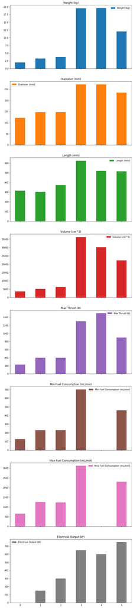

```python
# Created by Shaunak Gadkari, 2019

# This is a python program that will print out weight data as a bar plot on the different jet engine models
# NOTE: This code doesn't run on your computer, I ran it on mine and exported the results.

# Load a table about jet models but with only numerical values
jmc_data_numerical = pd.read_csv('data/03_jet_models_numerical.csv')
jmc_data_numerical.plot.bar(rot=0, subplots=True, figsize=(10,50))
```

# Working Notes (DELETE THIS)

- engine PBS TJ23U (https://pbs.cz/en/our-business/aerospace/aircraftgines/jetgine-pbs-tj23u and https://www.pbs.cz/getmedia/660edbb9-4b1c-4484-8db0-534a71b39255/PBS_Turbojet-engine_TJ23U_EN.pdf.aspx?ext=.pdf )

# Sources

**General**

1. Engheim, E. (2019). Most Interesting Rocket Engines. Medium. Available at: https://medium.com/@Jernfrost/most-interesting-rocket-engines-93b01af7ae4c [Accessed 23 Jul. 2019].
2. Rafailov, Y. (2004). Acceleration That Would Kill a Human - The Physics Factbook. [online] Hypertextbook.com. Available at: https://hypertextbook.com/facts/2004/YuriyRafailov.shtml [Accessed 23 Jul. 2019].
3. Urbonas, J., Gresty (Dr.), M., Vitkauskas, P., Valiūtė, A. and Ellis, W. (2019). "Death by Rollercoaster" - The Euthanasia Coaster. [online] YouTube. Available at: https://youtu.be/eKmKLZOAT38 [Accessed 23 Jul. 2019].

**Jet Engine Spec Sheets**

1. PBS Group (2017). TJ23U TurboJet Engine. [online] PBS.CZ. Available at: https://www.pbs.cz/getmedia/660edbb9-4b1c-4484-8db0-534a71b39255/PBS_Turbojet-engine_TJ23U_EN.pdf [Accessed 24 Jul. 2019].
2. PBS Group (2017). TJ40-G1 Jet Engine. [online] PBS.CZ. Available at: https://www.pbs.cz/getmedia/e47db2ca-b200-43e8-a2e8-ebd4820fad86/PBS_Turbojet-engine_TJ40-G1_EN.pdf [Accessed 24 Jul. 2019].
3. PBS Group (2017). TJ40-G2 Jet Engine. [online] PBS.CZ. Available at: https://www.pbs.cz/getmedia/fc676eb2-eb2a-4ffb-a7ac-364a83606a06/PBS_Turbojet-engine_TJ40-G2_EN.pdf [Accessed 24 Jul. 2019].
4. PBS Group (2017). TJ100 Jet Engine. [online] PBS.CZ. Available at: https://www.pbs.cz/getmedia/3bf0621d-4146-4c90-b8d0-08a875fe6380/PBS_Turbojet-engine_TJ100_EN.pdf [Accessed 24 Jul. 2019].
5. PBS Group (2017). TJ150 Jet Engine. [online] PBS.CZ. Available at: https://www.pbs.cz/getmedia/27d922e1-9402-4b7a-b279-9e0f6517c190/PBS_Turbojet-engine_TJ150-_EN.pdf [Accessed 24 Jul. 2019].
6. PBS Group (2017). TJ150 Jet Engine. [online] PBS.CZ. Available at: https://www.pbs.cz/getmedia/27d922e1-9402-4b7a-b279-9e0f6517c190/PBS_Turbojet-engine_TJ150-_EN.pdf [Accessed 24 Jul. 2019].
7. PBS Group (2017). TJ150 Jet Engine. [online] PBS.CZ. Available at: https://www.pbs.cz/getmedia/27d922e1-9402-4b7a-b279-9e0f6517c190/PBS_Turbojet-engine_TJ150-_EN.pdf [Accessed 24 Jul. 2019].
8. PBS Group (2017). TJ150 Jet Engine. [online] PBS.CZ. Available at: https://www.pbs.cz/getmedia/27d922e1-9402-4b7a-b279-9e0f6517c190/PBS_Turbojet-engine_TJ150-_EN.pdf [Accessed 24 Jul. 2019].